# Composition Analysis of melinda dated 2025-11-23

# Overall summary

8,366,642 records and 550,507,686 attribute values in total. Constituent files:

- data/melinda/melinda.parquet (1.42GB)

## Temporal overview

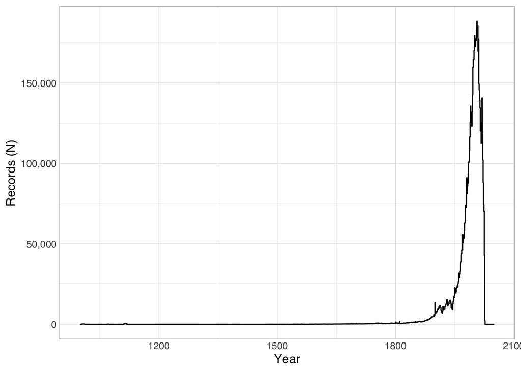

262,725 records do not have easily parseable dates between the years 1000 and 2050.

## Language overview

| [] | Records (N) | Proportion (%) |
| --- | --- | --- |
| fin (Finnish) | 2695808 | 0.322208422740786 |
| eng (English) | 2188234 | 0.261542152010737 |
| \|\|\| | 920887 | 0.110066276156349 |
| ger (German) | 536509 | 0.0641246404329374 |
| swe (Swedish) | 505627 | 0.0604335613534626 |
| zxx (No linguistic content; Not applicable) | 457663 | 0.0547008070963571 |
| rus (Russian) | 267898 | 0.0320197106156711 |
| fre (French) | 182319 | 0.0217911355058214 |
|  | 117974 | 0.0141004910084181 |
| lat (Latin) | 59700 | 0.00713546470580431 |

[output cut: 488 more lines]

# Field code usage overview

In total, 388 distinct fields are used.

Legend for the table below:

- `records`: how many records have at least one of this field
- `r_p`: the above as a percentage of all records
- `n`: the total number of appearances of this field
- `vals_per_rec`: calculated from the above, the mean number of appearances of this field per record
- `recs_with_mult_vals`: the number of records that have more than one repetition of this field

| field_code | field_description | records | r_p | n | vals_per_rec | recs_with_mult_vals |
| --- | --- | --- | --- | --- | --- | --- |
| <a name=" 01"> 01</a> | NA | 5 | 5.97611323634978e-07 | 5 | 1 | 0 |
| <a name="001" href="https://www.loc.gov/marc/bibliographic/bd001.html">001</a> | Control Number | 8366642 | 1 | 8366642 | 1 | 0 |
| <a name="002">002</a> | NA | 6 | 7.17133588361974e-07 | 6 | 1 | 0 |
| <a name="003" href="https://www.loc.gov/marc/bibliographic/bd003.html">003</a> | Control Number Identifier | 8366642 | 1 | 8366642 | 1 | 0 |
| <a name="004">004</a> | NA | 19 | 2.27092302981292e-06 | 19 | 1 | 0 |
| <a name="005" href="https://www.loc.gov/marc/bibliographic/bd005.html">005</a> | Date and Time of Latest Transaction | 8366642 | 1 | 8366754 | 1.00001338649365 | 95 |
| <a name="006" href="https://www.loc.gov/marc/bibliographic/bd006.html">006</a> | Additional Material Characteristics | 115434 | 0.013796933106496 | 116618 | 1.01025694336157 | 1104 |
| <a name="007" href="https://www.loc.gov/marc/bibliographic/bd007.html">007</a> | Physical Description | 3317849 | 0.396556826502198 | 3374216 | 1.01698901909038 | 46660 |
| <a name="008" href="https://www.loc.gov/marc/bibliographic/bd008.html">008</a> | General Information | 8366604 | 0.99999545815394 | 8366621 | 1.00000203188773 | 16 |
| <a name="009">009</a> | NA | 1 | 1.19522264726996e-07 | 1 | 1 | 0 |

[output cut: 378 more lines]

# Field code usage overview by subfield

In total, 2,857 distinct field+subfield combinations are used.

Legend for the table below:

- `records`: how many records have at least one of this field+subfield
- `r_p`: the above as a percentage of all records
- `dist_vals`: the number of different values appearing in this field+subfield
- `e_vals`: at most seven random sample values of this field+subfield
- `n`: the total number of appearances of this field+subfield
- `vals_per_rec`: calculated from the above, the mean number of appearances of this field+subfield per record
- `recs_with_mult_vals`: the number of records that have more than one repetition of this field+subfield

| subfield_code | subfield_description | records | r_p | dist_vals | e_vals | n | vals_per_rec | recs_with_mult_vals |
| --- | --- | --- | --- | --- | --- | --- | --- | --- |
| 01: NA |  |  |  |  |  |  |  |  |
| 01$a | NA | 5 | 0% | 4 | 012570258 (1)\|003208462 (1)\|004598485 (1)\|018972913 (2) | 5 | 1 | 0 |
| [001: Control Number](https://www.loc.gov/marc/bibliographic/bd001.html) |  |  |  |  |  |  |  |  |
| 001$ | NA | 8,366,642 | 100% | 8,258,331 | 000456977 (1)\|015253148 (1)\|017856033 (1)\|009484726 (1)\|009168461 (1)\|001529900 (1)\|001714754 (1) | 8,366,642 | 1 | 0 |
| 002: NA |  |  |  |  |  |  |  |  |
| 002$ | NA | 6 | 0% | 6 | seq00132121 (1)\|seq00290969 (1)\|har200437412 (1)\|00186374 (1)\|har210093082 (1)\|ybp21248362 (1) | 6 | 1 | 0 |
| [003: Control Number Identifier](https://www.loc.gov/marc/bibliographic/bd003.html) |  |  |  |  |  |  |  |  |
| 003$ | NA | 8,366,642 | 100% | 1 | FI-MELINDA (8,366,642) | 8,366,642 | 1 | 0 |
| 004: NA |  |  |  |  |  |  |  |  |
| 004$ | NA | 19 | 0% | 17 | aFI-NL (1)\|NOVANETb17409928 (1)\|BJB0842 (1)\|0 dFI-NLD (1)\|NOVANETb17502998 (1)\|2 afinbd (1)\|rnae (1) | 19 | 1 | 0 |
| [005: Date and Time of Latest Transaction](https://www.loc.gov/marc/bibliographic/bd005.html) |  |  |  |  |  |  |  |  |
| 005$ | NA | 8,366,642 | 100% | 7,120,559 | 20230921002808.0 (1)\|20240808064528.0 (1)\|20250319101655.0 (1)\|20230920174659.0 (1)\|20241212120435.0 (1)\|20250225001907.0 (1)\|20250814114756.0 (1) | 8,366,754 | 1 | 95 |
| [006: Additional Material Characteristics](https://www.loc.gov/marc/bibliographic/bd006.html) |  |  |  |  |  |  |  |  |
| 006$ | NA | 115,434 | 1.38% | 1,443 | i\|\|\|\|\|\|z \|\| \| (1)\|a\|\|\|\|g \|\|\|\| 000\|0 (1)\|i\|\|\|\|\|s\|\|\|\|\|\|\|\| \| (4)\|i\|\|\|\|d\|\|\|\|\|\|\|j\| \| (1)\|s\|\| \|\|\|\|\|\|\|\|\| \|\| (8)\|a j \|000 f (1)\|aa r\|\|\|\|\|\… | 116,618 | 1.01 | 1,104 |
| [007: Physical Description](https://www.loc.gov/marc/bibliographic/bd007.html) |  |  |  |  |  |  |  |  |
| 007$ | NA | 3,317,849 | 39.66% | 2,817 | cj ua-\|\|\|\|\|\|\|\| (1)\|co \|\|\|---aucuu (1)\|sd f\|\|gl\|\|m\|\|d (3)\|sd bsmennmp\|\|e (2)\|vu cga\|\|\| (1)\|co nuu---uuauu (28)\|sd \|\|\|\|\|\|\|p\|\|d (97) | 3,374,216 | 1.02 | 46,660 |
| [008: General Information](https://www.loc.gov/marc/bibliographic/bd008.html) |  |  |  |  |  |  |  |  |
| 008$ | NA | 8,366,604 | 100% | 3,207,634 | 160607s2012 xxu\|\|\|\| \|000\|0\|eng\|c (1)\|080304s1998 xxk\|\|\|\|\|\|\|\|\|\|\|\|\|\|\|0\|eng\|\| (1)\|941003s1994 dk \|\|\|\|\|\|\|\|\|\|\|\|\|\|\|0\|dan\|\| (1)\|901009s1941 it \|\|\|\|\|\|\|\|\… | 8,366,621 | 1 | 16 |
| 009: NA |  |  |  |  |  |  |  |  |
| 009$ | NA | 1 | 0% | 1 | 1837126 (1) | 1 | 1 | 0 |
| [010: Library of Congress Control Number](https://www.loc.gov/marc/bibliographic/bd010.html) |  |  |  |  |  |  |  |  |
| 010$a | LC control number | 34,458 | 0.41% | 33,674 | 73412400 (1)\|2006283975 (1)\|2012015530 (1)\|2012440816 (2)\|75032796 (1)\|2010022798 (1)\|2023945203 (1) | 34,464 | 1 | 6 |
| 010$b | NUCMC control number | 3 | 0% | 2 | 794366464 (2)\|fin (1) | 3 | 1 | 0 |
| 010$z | Cancelled/invalid LC control number | 61 | 0% | 61 | sn 90016413 (1)\|sn 88007120 (1)\|2015016307 (1)\|2021940848 (1)\|sn 87036116 (1)\|sn 85021627 (1)\|97123875 (1) | 63 | 1.03 | 2 |
| [013: Patent Control Information](https://www.loc.gov/marc/bibliographic/bd013.html) |  |  |  |  |  |  |  |  |
| 013$a | Number | 3 | 0% | 2 | it 51459516 (2)\|8106775 (1) | 3 | 1 | 0 |
| [015: National Bibliography Number](https://www.loc.gov/marc/bibliographic/bd015.html) |  |  |  |  |  |  |  |  |
| 015$2 | NA | 445,767 | 5.33% | 14 | sti (2)\|Книжная летопись (1)\|bnf (3)\|GyFmDB (2)\|can (16)\|bnb (1,029)\|kl (1) | 449,494 | 1.01 | 3,625 |
| 015$a | National bibliography number | 447,109 | 5.34% | 438,313 | fx645196 (1)\|fx711265 (1)\|f447606 (1)\|fx122485 (1)\|fx691758 (1)\|f759424 (1)\|fx695974 (1) | 450,940 | 1.01 | 3,714 |
| 015$g | NA | 1 | 0% | 1 | pehmeäkantinen (1) | 1 | 1 | 0 |

[output cut: 3215 more lines]